# ISA 401: Business Intelligence & Data Visualization

# Part 1: Data Frames and Lists

# From Vectors to a Data Frame

```
crashes_df = tibble::tibble(  day     = names(crashes_by_day),  crashes = crashes_by_day,  busy    = crashes_by_day > 2000)crashes_df
```

```
# A tibble: 7 × 3
  day   crashes busy
  <chr>   <dbl> <lgl>
1 Mon      2020 TRUE
2 Tue      2241 TRUE
3 Wed      2327 TRUE
4 Thu      2285 TRUE
5 Fri      2380 TRUE
6 Sat      1866 FALSE
7 Sun      1664 FALSE
```

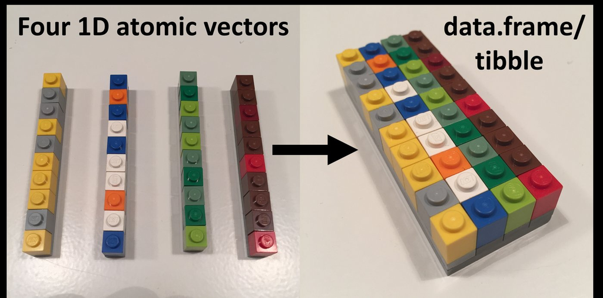

Vectors standing side by side

Each **column** is one vector with one type (`<chr>`, `<dbl>`, `<lgl>` in the header). All columns have the **same length**, so every row lines up.

The crash file is the same thing with 30,125 rows and 13 columns. `tibble` is the tidyverse's data frame: same object, tidier printing. **Part 2:** taking these apart (pick a column, pick rows).

<html>
<hr>
</html>
**Image:** Jenny Bryan, [lego-rstats](https://github.com/jennybc/lego-rstats#readme).

# Looking at a Data Frame

```
nrow(crashes_df)             # how many rows?ncol(crashes_df)             # how many columns?colnames(crashes_df)         # what are they called?typeof(crashes_df)           # what is it, underneath?
```

```
[1] 7
[1] 3
[1] "day"     "crashes" "busy"
[1] "list"
```

```
dplyr::glimpse(crashes_df)   # one line per column
```

```
Rows: 7
Columns: 3
$ day     <chr> "Mon", "Tue", "Wed", "Thu", "Fri",…
$ crashes <dbl> 2020, 2241, 2327, 2285, 2380, 1866…
$ busy    <lgl> TRUE, TRUE, TRUE, TRUE, TRUE, FALS…
```

Four questions for any data frame

How many rows, how many columns, what are they called, and what type is each. `dplyr::glimpse()` answers all four in one call and is the first thing to run on data you did not build yourself.

**`typeof(crashes_df)` says `"list"`.** A data frame is a **named list of vectors** with one extra rule: every vector has the same length. Drop that rule and you get a plain list, which is next.

# A List Holds Anything

```
example_list = list(  1:3,                    # integers 1, 2, 3  "a",                    # one piece of text  c(TRUE, FALSE, TRUE),   # three logicals  c(2.3, 5.9)             # two decimals)str(example_list)         # the x-ray view
```

```
List of 4
 $ : int [1:3] 1 2 3
 $ : chr "a"
 $ : logi [1:3] TRUE FALSE TRUE
 $ : num [1:2] 2.3 5.9
```

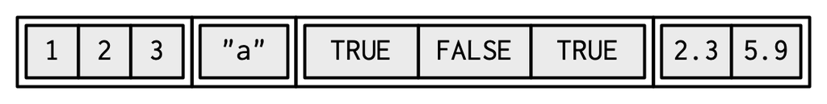

Every element its own shape

A vector holds **one type, one length**. A list holds **anything**: vectors of different types and lengths, and even other lists.

`str()` prints one line per element with its type and length. Run it on anything you do not recognize; it is the fastest way to learn what an object is made of.

<html>
<hr>
</html>
**Image:** Hadley Wickham, [Advanced R, chapter 3 (Lists)](https://adv-r.hadley.nz/vectors-chap.html#lists).

# `[ ]` vs `[[ ]]` on a List

```
str(example_list[1])     # [ ]  the shaker: a list of 1
```

```
List of 1
 $ : int [1:3] 1 2 3
```

```
str(example_list[[1]])   # [[ ]] the packet: the element
```

```
 int [1:3] 1 2 3
```

```
example_list[[1]][[1]]   # the pepper: first value in it
```

```
[1] 1
```

```
example_list[[4]][2]     # element 4, then its 2nd value
```

```
[1] 5.9
```

[figure not shown]

The pepper shaker rule

`x` is the shaker. `x[1]` is a shaker with one packet: **still a list**. `x[[1]]` is the packet itself. `x[[1]][[1]]` is the pepper.

When the list has **names**, `x$name` is `x[["name"]]` with less typing. Next slide.

<html>
<hr>
</html>
**Image:** Hadley Wickham, [indexing lists in R](https://twitter.com/hadleywickham/status/643381054758363136).

# Examine a Job Ad

```
job = list(  title   = "Research Data Scientist, Magic Eye",  company = "Google",  salary  = list(min = 147000, max = 210000))str(job)
```

```
List of 3
 $ title  : chr "Research Data Scientist, Magic Eye"
 $ company: chr "Google"
 $ salary :List of 2
  ..$ min: num 147000
  ..$ max: num 210000
```

Write one expression to extract each of

**1.** The company name.

**2.** The maximum salary.

**3.** The maximum salary again, using only `[[ ]]`.

**4.** The names of the elements in `job`.

Type them in a chunk in your markdown and run each line. The ad is the Google posting from Class 01.

<details class="answer-gate" style="margin-top:4px;"><summary style="cursor:pointer; font-weight:700; color:#c3142d; font-size:16px;">Answer will be shown in class</summary>

```
job$company                   # 1job$salary$max                # 2: a list inside a listjob[["salary"]][["max"]]      # 3: the same path, by namenames(job)                    # 4
```

```
[1] "Google"
[1] 210000
[1] 210000
[1] "title"   "company" "salary"
```

Reading a path

Each `$` or `[[ ]]` steps one level down. `job$salary$max` reads: in `job`, take `salary`, then take `max`.

Also correct: `job[["company"]]`, `job$salary[["max"]]`, `job[[3]]$max`.

</details>

- Notes from our class discussion (Use Chrome as your browser to edit this part of the page)

# Part 2: Subsetting and Indexing

# Subsetting a Vector

```
crashes_by_day = c(2020, 2241, 2327, 2285, 2380, 1866, 1664)names(crashes_by_day) = c("Mon", "Tue", "Wed", "Thu",                          "Fri", "Sat", "Sun")crashes_by_day[2]                      # one position
```

```
 Tue
2241
```

```
crashes_by_day["Fri"]                  # by name
```

```
 Fri
2380
```

```
crashes_by_day[crashes_by_day > 2300]  # by condition
```

```
 Wed  Fri
2327 2380
```

Three things that can go inside [ ]

**One position**, counting from 1, not 0.

**A name**, when the vector has names.

**A condition**: a TRUE/FALSE vector as long as the original keeps the positions where it is TRUE.

The first two lines rebuild `crashes_by_day` so this slide stands on its own. Several positions go in with `c()`, as in `[c(1, 7)]`; a negative position such as `[-1]` drops instead of keeps.

# Subsetting a Data Frame

```
crashes_df = tibble::tibble(  day     = names(crashes_by_day),  crashes = crashes_by_day,  busy    = crashes_by_day > 2000)crashes_df$crashes                     # one column, as a vector
```

```
 Mon  Tue  Wed  Thu  Fri  Sat  Sun
2020 2241 2327 2285 2380 1866 1664
```

```
crashes_df[["crashes"]]                # the same vector, by name
```

```
 Mon  Tue  Wed  Thu  Fri  Sat  Sun
2020 2241 2327 2285 2380 1866 1664
```

```
crashes_df[1:2, c("day", "crashes")]   # rows 1 to 2, two columns
```

```
# A tibble: 2 × 2
  day   crashes
  <chr>   <dbl>
1 Mon      2020
2 Tue      2241
```

`$` and `[[ ]]` open one column into a vector. `[rows, columns]` hands back a smaller tibble; leave a side of the comma empty to keep all of it.

# One Table for Three Brackets

What comes back depends on the object and on the bracket. Read across a row for one object, down a column for one bracket.

| Object | [ ] | [[ ]] | $ |
|:--|:--|:--|:--|
| **Vector** `crashes_by_day` | a shorter **vector** | one element (rarely needed) | not allowed |
| **List** `example_list`, `job` | a shorter **list** | one element, whatever it is | one **named** element, same as `[["name"]]` |
| **Data frame** `crashes_df` | a smaller **data frame** `[rows, columns]` | one column as a **vector** | one column as a **vector** |

**Rule of thumb**

- `[ ]` **keeps the container**: a smaller vector, list, or data frame of the same kind.
- `[[ ]]` and `$` **open the container**: you get what is inside.
- The pepper shaker again: one bracket is still a shaker, two brackets is the packet.